# How to talk like a certain school of philosophy

Name : Ting Han Ko  
Uni: tk2944

Philosophy is not an easy topic and it is not easy to speak like one. This project is dedicated to help someone who's interested in identifying different schools and try to speak like one. To begin with, I do not have any philosophical training or education profound enough to allow me to make judgement on how to speak like a philosopher. However, I was thinking perhaps we can all learn something mechanically from the data. We will ask the computer to read those senteces for us even before we understand what it actually means, and then computer could tell us what can possibly be the characteristics of each school.

Through the analysis maybe we could learn philosophy in a more efficient way and we could even provide this result to expert and see if they agree with our findings. Eventually, I would like to see if I can talk like a certain school.

## 1. About the data

This dataset was obtained from kaggle, which was originally collected and used for the Philosophy Data Project and that website. The former philosophy teacher, Kourosh Alizadeh, made the data publicly available so others could work with it.

The dataset contains over 300,000 sentences from over 50 texts spanning 13 major schools of philosophy. The represented schools are: 'analytic', 'aristotle', 'capitalism', 'communism', 'continental', 'empiricism', 'feminism', 'german_idealism', 'nietzsche', 'phenomenology', 'plato', 'rationalism', 'stoicism'

Originally the first five rows of the data looks like this:

|  | title | author | school | sentence_spacy | sentence_str | original_publication_date | corpus_edition_date | sentence_length | sentence_lowered | tokenized_txt | lemmatized_str |
| --- | --- | --- | --- | --- | --- | --- | --- | --- | --- | --- | --- |
| 0 | Plato - Complete Works | Plato | plato | What's new, Socrates, to make you leave your ... | What's new, Socrates, to make you leave your ... | -350 | 1997 | 125 | what's new, socrates, to make you leave your ... | ['what', 'new', 'socrates', 'to', 'make', 'you... | what be new , Socrates , to make -PRON- lea... |
| 1 | Plato - Complete Works | Plato | plato | Surely you are not prosecuting anyone before t... | Surely you are not prosecuting anyone before t... | -350 | 1997 | 69 | surely you are not prosecuting anyone before t... | ['surely', 'you', 'are', 'not', 'prosecuting',... | surely -PRON- be not prosecute anyone before ... |
| 2 | Plato - Complete Works | Plato | plato | The Athenians do not call this a prosecution b... | The Athenians do not call this a prosecution b... | -350 | 1997 | 74 | the athenians do not call this a prosecution b... | ['the', 'athenians', 'do', 'not', 'call', 'thi... | the Athenians do not call this a prosecution ... |
| 3 | Plato - Complete Works | Plato | plato | What is this you say? | What is this you say? | -350 | 1997 | 21 | what is this you say? | ['what', 'is', 'this', 'you', 'say'] | what be this -PRON- say ? |
| 4 | Plato - Complete Works | Plato | plato | Someone must have indicted you, for you are no... | Someone must have indicted you, for you are no... | -350 | 1997 | 101 | someone must have indicted you, for you are no... | ['someone', 'must', 'have', 'indicted', 'you',... | someone must have indict -PRON- , for -PRON- ... |

## 1a. Data Cleaning and processing

The data was originally processed and cleaned by the professor Kourosh Alizadeh who kindly provided the data to all the data scientists.

The data will be used in two format here- one that will be used here was processed by combining all the senteces within one school; the other one was processed by taking the average of the length of sentence of eacah school, as it will be shown later below.

## 2. Top words

During the cleaning process, we can stop and look at the most common top words in every schools --> perhaps add them to the stop word list  
These are the most common words said in every schools. Let's see if we can learn anything from them.

```
[('time', 12),
 ('does', 8),
 ('things', 8),
 ('thing', 8),
 ('man', 8),
 ('way', 7),
 ('world', 7),
 ('men', 7),
 ('body', 6),
 ('nature', 6),
 ('reason', 6),
 ('say', 5),
 ('truth', 5),
 ('like', 5),
 ('possible', 5),
 ('good', 5),
 ('great', 5),
 ('life', 5),
 ('true', 4),
 ('sense', 4),
 ('use', 4),
 ('just', 4),
 ('power', 4),
 ('means', 4),
 ('knowledge', 4),
 ('make', 4),
 ('case', 3),
 ('know', 3),
 ('different', 3),
 ('certain', 3)]
```

While it is interesting to look at these very common words, it seems like they do not really meant anything yet. Therefore, I will add them to the stop words so I can remove those words from the sentences and start the analysis from there.

#### take away #1

However, we do learn that if we want to talk like a philosopher we should try to include these words in our senteces as much as possible!

## 2a. Top words for each school

Let's find out what are the more unique top words in each school, after removing the first few top wrods appeared in every schools.

```
analytic
say, true, sense, case, theory, know, language, fact, different, truth, certain, think, like, question, possible, given, belief, statements, use, sentence, meaning, example, proposition, just, words, knowledge, word, make, terms
---
aristotle
good, animals, case, like, body, say, nature, motion, parts, water, said, reason, just, place, kind, possible, sense, number, movement, true, air, animal, called, belong, cause, come, state, heat, form
---
capitalism
price, money, labour, value, great, capital, country, quantity, produce, greater, trade, rate, land, different, wages, rent, corn, tax, employment, goods, people, proportion, demand, market, commodities, stock, increase, revenue, silver
---
communism
labour, value, capital, production, power, work, form, working, means, social, money, capitalist, day, state, commodities, hours, surplus, commodity, class, process, hand, industry, number, political, workers, use, labourer, factory, great
---
continental
madness, form, language, order, difference, nature, thought, representation, possible, knowledge, sense, relation, new, forms, body, century, history, reason, truth, longer, point, social, question, general, repetition, fact, like, desire, life
---
empiricism
ideas, idea, mind, reason, make, nature, power, knowledge, certain, shall, objects, different, think, object, use, great, body, particular, existence, general, matter, present, parts, qualities, words, motion, know, distinct, cause
---
feminism
woman, women, life, love, like, black, mother, male, little, husband, girl, young, children, white, child, sexual, work, female, body, human, make, wife, womens, great, did, marriage, reason, people, nature
---
german_idealism
concept, self, reason, nature, consciousness, object, pure, form, existence, unity, universal, just, merely, law, determination, content, general, thought, understanding, absolute, possible, relation, means, cognition, given, subject, principle, concepts, immediate
---
nietzsche
thou, ye, life, zarathustra, god, good, like, great, did, ones, love, hath, thy, say, people, unto, spirit, thee, day, self, soul, truth, means, new, old, long, power, know, fact
---
phenomenology
dasein, consciousness, beings, sense, present, knowledge, experience, object, self, meaning, life, body, truth, science, possible, subject, essence, means, fact, existence, thought, perception, hand, understanding, question, objective, natural, true, sein
---
plato
say, said, good, think, just, socrates, people, like, know, dont, make, soul, right, come, knowledge, city, kind, gods, life, isnt, sort, case, thats, true, tell, different, state, person, better
---
rationalism
god, mind, body, nature, good, reason, order, soul, idea, bodies, cause, know, ideas, true, certain, love, motion, say, make, necessary, said, truth, power, far, different, knowledge, great, objects, just
---
stoicism
thou, unto, thy, thee, nature, doth, good, thyself, whatsoever, shall, mind, life, hath, art, shalt, reason, common, true, let, power, proper, according, use, say, hast, kind, happen, did, consider
---
```

Now we have a list of words to learn if we want to talk like them, but maybe we can start with the words that appear most frequently, as shown in the word cloud:

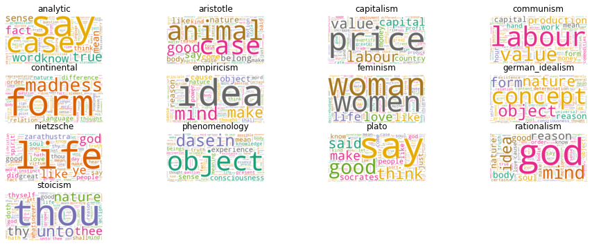

#### takeaway #2

This is an interesting findings, let us take a few examples of how we can utilize these word clouds. It is as expected that feminism talks more about 'Woman' or 'Women'. Communism talks more about 'Labour' and capitalism talks more about 'price'.

This is a great start for us to learn their words usages and perhaps topics. For example, I have never been taught what the empiricism is, but from this word cloud if I want to talk like them, I could maybe speak more about idea, mind, and objects, and then if we look at the broader list I should probably also include words like existence, motions etc.

## 3. Length of senteces

In addition to the content, perhaps we could also adjust the length of our sentences to sound more like a true philosopher. First, we will need to see how many words. Since according to a scientist Wolf Garbe the average word length in English language is 4.7 characters, we will use this as a reference to see roughly how many words we should say in a sentence to achieve the result.

Let's first look at the average length of sentence and find out who talk the most and the less.

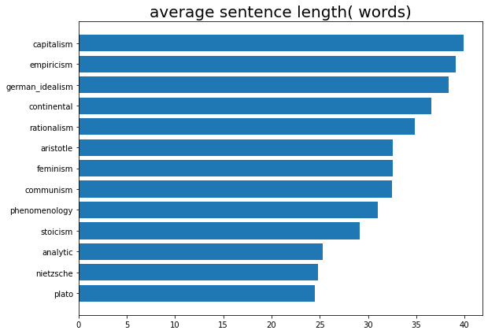

#### takeaway #3

This tells us that capitalism talk the most in one sentence and plato talk the least. We can also utilize this for other schools. For example, to continue my learning journey for empiricism, I would say I shoud talk more than I used to and should include almost 40 words on average everytime in my sentence.

## 4. Sentiment Analysis

Now we can move to a deeper concept-- what kind of sentiment is represented in each school? It is not enough for us just to simply look at a few words and the length, now we're going to also look at the overall positivity and subjectivity of the content. Below shows the analysis plot of subjectivity and polarity overview:

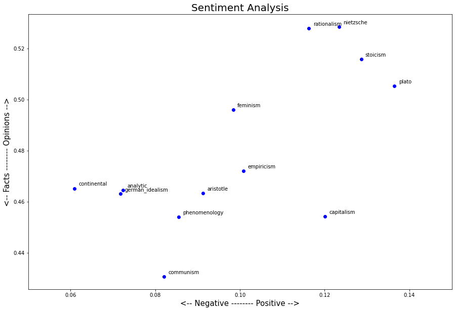

#### takeaway #4

From this graph we can see a few schools are more closely positioned with one another. Interestingly, communism is more objective compared to otehr schools, and plato seems to be the most positive one in comparison. If I want to talk like a empiricism, according to the graph, I will just pick the most middle ground for every speech and try to be only moderately positive and moderately subjective.

## 5. Topic Modeling

#### Topic modeling attempt with nouns and adjectives

I have experiment many attempts with different words, and have found that for now adjectives and noun descride the topics in the best way possible for me to conduct this analysis. Therefore, I will include only noun and adjective in the sentences and test out which has the best topics identified, again, this will be based on my sole judgement and my limited knowegde in this matter.

I have not figure out a good way to visualize this, but essentially based on my testings I figured that four topics is the best findings for now, since it has the clearest results, which generate broad but clear topics. Therefore, we will go for four topics here, and I will name the topics based on the kep words and my own understanding for english words.

```
[(0,
  '0.005*"socrates" + 0.005*"female" + 0.004*"perception" + 0.003*"moisture" + 0.003*"sexual" + 0.002*"sensations" + 0.002*"eggs" + 0.002*"thats" + 0.002*"dont" + 0.002*"contraries"'),
 (1,
  '0.008*"concepts" + 0.008*"cognition" + 0.007*"dasein" + 0.007*"determinateness" + 0.006*"empirical" + 0.006*"determinations" + 0.006*"judgement" + 0.006*"transcendental" + 0.006*"perception" + 0.006*"subjective"'),
 (2,
  '0.011*"commodities" + 0.008*"rent" + 0.007*"commodity" + 0.007*"tax" + 0.006*"capitalist" + 0.006*"profits" + 0.006*"revenue" + 0.005*"england" + 0.005*"consumption" + 0.005*"labourer"'),
 (3,
  '0.009*"madness" + 0.005*"statements" + 0.003*"empirical" + 0.003*"classical" + 0.003*"causal" + 0.002*"unconscious" + 0.002*"perception" + 0.002*"beliefs" + 0.002*"role" + 0.002*"paper"')]
```

Four topics seem to make the most sense after a few rounds of examinations and classifications. I named the topics based on the keywords that are shown in the background calculation with each collection. There are four topics that I identified: 1. Sex and Female 2. Concepts 3. Economics 4. Opinions and analytics.

#### Identify topics in each documents

Here are the topics we end up with according to a few rounds of testing and my limited philosophy and english knowledge.

- Topic 0: Sex and Female
- Topic 1: Concepts
- Topic 2: Economics
- Topic 3: Opinions and analytics

We will try to let computer tell us which school use more words in which topics.

```
[([(3, 0.99999225)], 'analytic'),
 ([(0, 0.9999901)], 'aristotle'),
 ([(2, 0.9999856)], 'capitalism'),
 ([(2, 0.9999858)], 'communism'),
 ([(3, 0.99916875)], 'continental'),
 ([(0, 0.9985646)], 'empiricism'),
 ([(0, 0.8424933), (2, 0.10716002), (3, 0.050341725)], 'feminism'),
 ([(1, 0.99999136)], 'german_idealism'),
 ([(0, 0.3007933), (1, 0.6991868)], 'nietzsche'),
 ([(1, 0.99998784)], 'phenomenology'),
 ([(0, 0.9999835)], 'plato'),
 ([(0, 0.99997723)], 'rationalism'),
 ([(0, 0.2939842), (1, 0.70588875)], 'stoicism')]
```

From the computation result in the background, we can conclude that each schools contain one or two topics as below:

- Topic 0: Sex and Female -- aristotle, empiricism, feminism, nietzsche, plato, rationalism, stoicism
- Topic 1: Concepts -- german_idealism, phenomenology, nietzsche, stoicism
- Topic 2: Economics -- communism, capitalis
- Topic 3: Opinions and analytics -- analytic, continental

#### Takeaway #5

The most interesting finding is perhaps that a lot of schools really associate femail and sex or at least mention them together a lot. One could possibly guess that some of these schools had sexualized female the most. However, in a broader aspect, I do think it is helpful to look at what topics/ keywords they mention in each school. For instance, as expected Communism and apitalism talk about economics all the time. For another example, to continue my journey of speaking like a empiricism, I would have to talk mention sex and female more.

## Conclusion

There are a lot of information we can extract from the analysis. To simply answer my question in the beginning, how to talk like a specific school?, we can narrow it down to a few points below:

1. Choose the right topics: communism, capitalism --> economics ; idealism --> Concepts
2. Choose a right length to talk: capitalism, empiricism --> long ; Plato, Nietzsche --> short
3. Choose the right attitude: Plato, Stoicism --> positive ; continental --> negative
4. Choose a good word and use frequently: Analytics --> 'case'

Hopefully someone study philosophy can comment on whether this is a fair result or not!

[output not shown]